# Comparisons of rainfall regime among vegetation types and Biomes

Marcio

2023-07-17

#### Here, we investigate differences in mean annual precipitation (MAP) and Markham seasonality index (MSI) (Markham, 1970) between the Amazon biome (Map 1, blue line), the Cerrado biome (Map 1, red line), the Caatinga biome (Map 1, purple line) and three vegetation types (black dot in the Map 1) within the Cerrado (i.e. Savanna, Gallery Forest, and Dry Forest all from the [PNCV](https://www.icmbio.gov.br/parnachapadadosveadeiros/guia-do-visitante.html)).

**Map 1** MAP (a) and MSI (b) for the region of study. Red line depicts the Cerrado border, the blue line corresponds to Amazon border, purple line to Caatinga border and the black dot is placed in the Parque Nacional da Chapada dos Veadeiros (PNCV). Monthly precipitation for South America from CHIRPS V2.0.

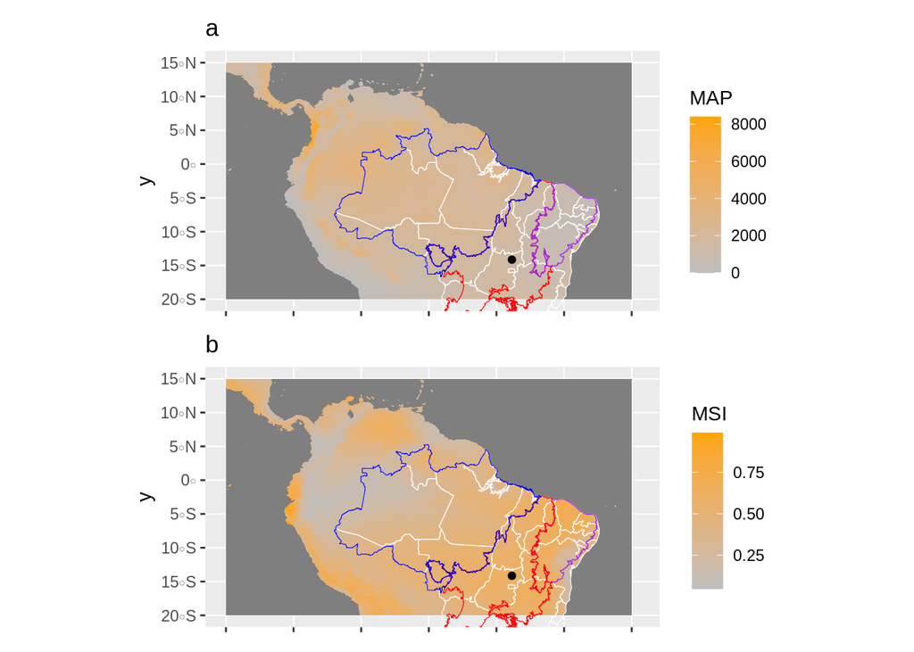

### **Methods and Results**

The visual inspection of the residuals distribution shows that for MAP (Figure 1a) it is normaly distributed, with the mean near zero. For the MSI, residuals presented a tailed distribution and to deal with heterocedasticity of residuals we used the function *exp* to transform the data (Figure 1b).

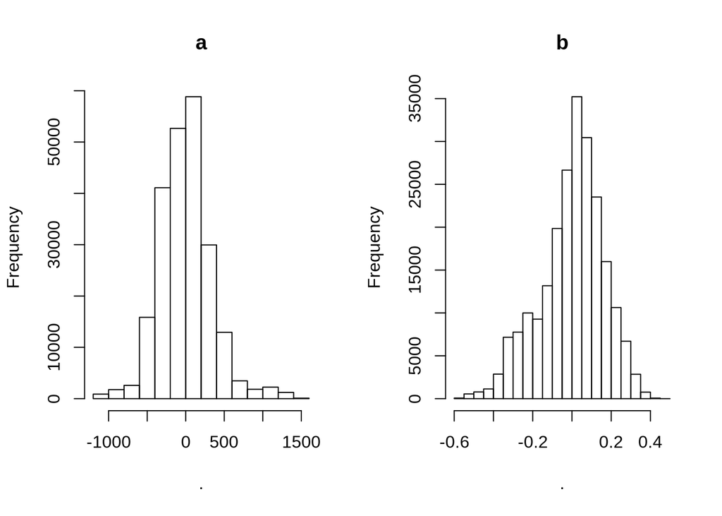

Figure 1: Residuals inspection.

## MAP

```r
m1 <- nlme::gls(Rainfall ~ as.factor(Biome),
    data = data,
    weights = nlme::varIdent(form = ~ 1 | as.factor(Biome)),
    method = "ML", na.action = na.omit)

summary(m1)$tTable %>% knitr::kable()
```

|  | Value | Std.Error | t-value | p-value |
| --- | --- | --- | --- | --- |
| (Intercept) | 2268.5796 | 1.053557 | 2153.2581 | 0 |
| as.factor(Biome)Caatinga | -1577.1555 | 1.445449 | -1091.1179 | 0 |
| as.factor(Biome)Cerrado | -832.1394 | 1.516494 | -548.7260 | 0 |
| as.factor(Biome)Dry Forest | -972.7419 | 19.925029 | -48.8201 | 0 |
| as.factor(Biome)Gallery Forest | -867.0943 | 2.885341 | -300.5171 | 0 |
| as.factor(Biome)Savanna | -859.5753 | 2.113434 | -406.7198 | 0 |

Next, we performed an analysis of variance (ANOVA) using the *anova* function in R to assess the statistical significance of the main effects of factors.

```r
an_m <- anova(m1)
an_m %>% data.frame %>% knitr::kable()
```

|  | numDF | F.value | p.value |
| --- | --- | --- | --- |
| (Intercept) | 1 | 6535985.7 | 0 |
| as.factor(Biome) | 5 | 238171.8 | 0 |

ANOVA revealed statistically significant differences (Table 2) and we proceeded with post hoc tests to conduct multiple comparisons between groups. For this purpose, we performed pairwise comparisons between factors with the *emmeans* function from the package *emmeans* (Lenth, 2022) to compute marginal means and confidence intervals for each combination of factors (Table 3).

```r
means <- emmeans::emmeans(m1, specs = list("Biome"))
means %>% data.frame %>% knitr::kable()
```

| Biome | emmean | SE | df | lower.CL | upper.CL |
| --- | --- | --- | --- | --- | --- |
| Amazon | 2268.5796 | 1.0535568 | 138088.10590 | 2265.8000 | 2271.3592 |
| Caatinga | 691.4241 | 0.9896169 | 28495.18816 | 688.8131 | 694.0352 |
| Cerrado | 1436.4402 | 1.0907662 | 59247.67705 | 1433.5624 | 1439.3180 |
| Dry Forest | 1295.8377 | 19.8971552 | 12.38576 | 1233.4788 | 1358.1965 |
| Gallery Forest | 1401.4852 | 2.6861143 | 11.10997 | 1392.8858 | 1410.0847 |
| Savanna | 1409.0042 | 1.8321083 | 12.08495 | 1403.2359 | 1414.7726 |

Subsequently, we conducted multiple comparison tests using the *contrast* function, also from *emmeans* package, with the argument *method = “pairwise”*. This test allowed us to identify significant differences between groups (or not) by comparing all factor levels, such as biomes and vegetation types. Adjusted p-values were considered to control the family-wise error rate by Tukey method (see [contrast-methods](https://www.rdocumentation.org/packages/emmeans/versions/1.8.7/topics/summary.emmGrid) from the package emmeans).

```r
contrasts <- emmeans::contrast(means, method = "pairwise")

contrasts %>%
  data.frame %>%
  rename(Pair = "emmeans.of.Biome.contrast") %>%
  rename(estimate = "emmeans.of.Biome.estimate") %>%
  rename(se = "emmeans.of.Biome.SE") %>%
  rename(df = "emmeans.of.Biome.df") %>%
  rename(`t ratio` = "emmeans.of.Biome.t.ratio") %>%
  rename(`p-value` = "emmeans.of.Biome.p.value")  %>% knitr::kable()
```

| Pair | estimate | se | df | t ratio | p-value |
| --- | --- | --- | --- | --- | --- |
| Amazon - Caatinga | 1577.155475 | 1.445449 | 102390.78352 | 1091.117868 | 0.0000000 |
| Amazon - Cerrado | 832.139410 | 1.516494 | 160995.80547 | 548.725977 | 0.0000000 |
| Amazon - Dry Forest | 972.741893 | 19.925029 | 12.45527 | 48.820100 | 0.0000000 |
| Amazon - Gallery Forest | 867.094348 | 2.885341 | 14.79007 | 300.517127 | 0.0000000 |
| Amazon - Savanna | 859.575345 | 2.113434 | 21.39806 | 406.719782 | 0.0000000 |
| Caatinga - Cerrado | -745.016065 | 1.472791 | 81755.45753 | -505.853311 | 0.0000000 |
| Caatinga - Dry Forest | -604.413582 | 19.921750 | 12.44713 | -30.339382 | 0.0000000 |
| Caatinga - Gallery Forest | -710.061127 | 2.862613 | 14.33063 | -248.046519 | 0.0000000 |
| Caatinga - Savanna | -717.580130 | 2.082297 | 20.16873 | -344.609824 | 0.0000000 |
| Cerrado - Dry Forest | 140.602483 | 19.927031 | 12.46039 | 7.055867 | 0.0001242 |
| Cerrado - Gallery Forest | 34.954938 | 2.899135 | 15.07896 | 12.057025 | 0.0000000 |
| Cerrado - Savanna | 27.435935 | 2.132227 | 22.16928 | 12.867268 | 0.0000000 |
| Dry Forest - Gallery Forest | -105.647545 | 20.077649 | 12.71369 | -5.261948 | 0.0017983 |
| Dry Forest - Savanna | -113.166548 | 19.981327 | 12.59476 | -5.663615 | 0.0009654 |
| Gallery Forest - Savanna | -7.519003 | 3.251435 | 18.00246 | -2.312518 | 0.2393606 |

We found differences in MAP between dry forests and both gallery forests and savannas (Table 4). Unexpectedly, the MAP of our samples are distinct from the MAP of both Biomes, including the Cerrado where they are located (Table 4).

Furthermore, we found that the MAP for more than half of all dry forests samples are outside the bistability zone (1300-2100 mm), i.e. the range of MAP in which forests and savannas may occur, defined by Ciemer et al. (2019) for the neotropics (Figure 2). However they are near the lower limit. Despite the unexpected differences in MAP for dry forests, most of our samples are inside the bistability zone for the neotropics (1300-2100mm; Ciemer et al., 2019) (Figure 2). By the other hand, Staver et al. (2011) defined a more wide range (1000-2500 mm), but using a global model. Thus, the limits defined by Staver et al. (2011) correctly includes dry forests into the bistability zone.

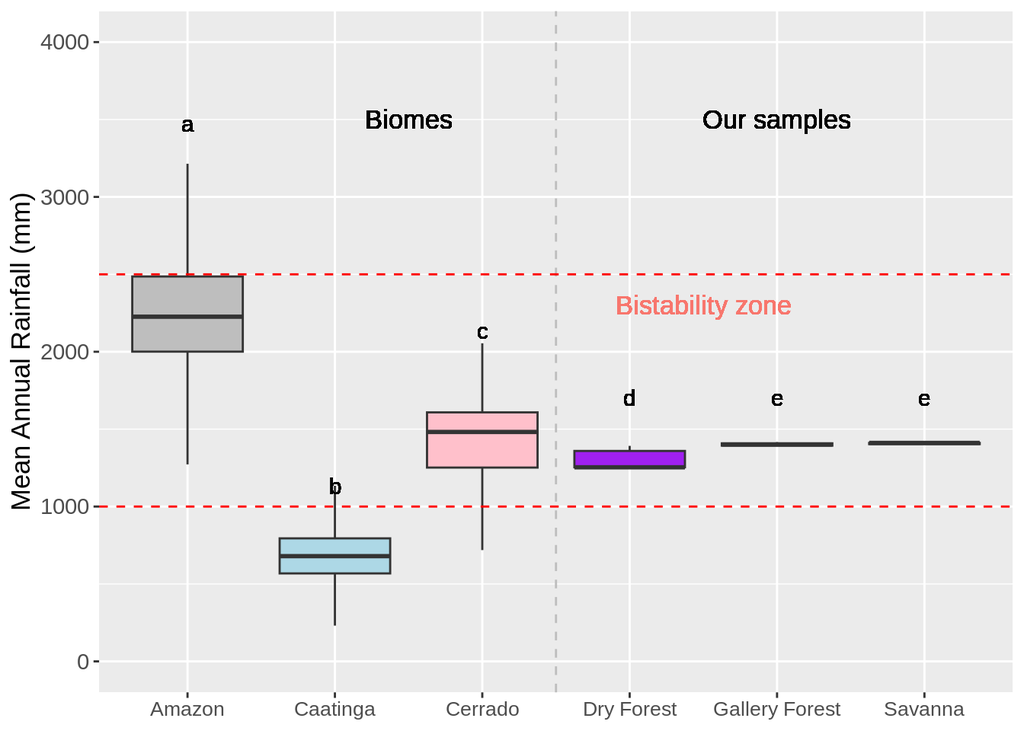

Figure 2: MAP distribution for Amazon, Caatinga and Cerrado Biomes, and for our sampled vegetation types. Red lines are the bistability zone defined by Staver et al. (2011).

## Markham Seasonality Index (MSI)

To compare between vegetation types and Biomes regardind MSI (i.e. seasonality lenght) (Markham, 1970), we performed the same method used to test for differences in MAP (Tables 5-8).

```r
m2 <- nlme::gls(exp(Rainfall) ~ as.factor(Biome),
    data = data1,
    weights = nlme::varIdent(form = ~ 1 | as.factor(Biome)),
    method = "ML", na.action = na.omit)

summary(m2)$tTable %>% knitr::kable()
```

|  | Value | Std.Error | t-value | p-value |
| --- | --- | --- | --- | --- |
| (Intercept) | 1.4846488 | 0.0004642 | 3197.9982 | 0 |
| as.factor(Biome)Caatinga | 0.3037148 | 0.0014085 | 215.6307 | 0 |
| as.factor(Biome)Cerrado | 0.2894743 | 0.0005671 | 510.4890 | 0 |
| as.factor(Biome)Dry Forest | 0.3248452 | 0.0031265 | 103.8992 | 0 |
| as.factor(Biome)Gallery Forest | 0.3262108 | 0.0012231 | 266.7144 | 0 |
| as.factor(Biome)Savanna | 0.3295360 | 0.0010822 | 304.5066 | 0 |

The ANOVA revealed significative differences among groups (Table 6).

```r
an_m <- anova(m2)
an_m %>% data.frame %>% knitr::kable()
```

|  | numDF | F.value | p.value |
| --- | --- | --- | --- |
| (Intercept) | 1 | 47773529.45 | 0 |
| as.factor(Biome) | 5 | 59169.47 | 0 |

```r
means <- emmeans::emmeans(m2, specs = list("Biome"))
means %>% data.frame %>% knitr::kable()
```

| Biome | emmean | SE | df | lower.CL | upper.CL |
| --- | --- | --- | --- | --- | --- |
| Amazon | 1.484649 | 0.0004642 | 1.336860e+05 | 1.483424 | 1.485874 |
| Caatinga | 1.788364 | 0.0013298 | 2.444528e+04 | 1.784855 | 1.791872 |
| Cerrado | 1.774123 | 0.0003256 | 5.886448e+04 | 1.773264 | 1.774982 |
| Dry Forest | 1.809494 | 0.0030919 | 8.823026e+00 | 1.799037 | 1.819951 |
| Gallery Forest | 1.810860 | 0.0011315 | 6.742534e+00 | 1.806689 | 1.815030 |
| Savanna | 1.814185 | 0.0009776 | 7.525629e+00 | 1.810718 | 1.817652 |

The comparisons among groups showed differences between biomes and between biomes and all sampled vegetation types (Table 8). Dry forests, gallery forests and savannas at the PNCV do not differ in terms of length of dry season.

```r
contrasts <- emmeans::contrast(means, method = "pairwise")

contrasts %>%
  data.frame %>%
  rename(Pair = "emmeans.of.Biome.contrast") %>%
  rename(estimate = "emmeans.of.Biome.estimate") %>%
  rename(se = "emmeans.of.Biome.SE") %>%
  rename(df = "emmeans.of.Biome.df") %>%
  rename(`t ratio` = "emmeans.of.Biome.t.ratio") %>%
  rename(`p-value` = "emmeans.of.Biome.p.value")  %>% knitr::kable()
```

| Pair | estimate | se | df | t ratio | p-value |
| --- | --- | --- | --- | --- | --- |
| Amazon - Caatinga | -0.3037148 | 0.0014085 | 3.087989e+04 | -215.630689 | 0.0000000 |
| Amazon - Cerrado | -0.2894743 | 0.0005671 | 1.921352e+05 | -510.488963 | 0.0000000 |
| Amazon - Dry Forest | -0.3248452 | 0.0031265 | 9.225340e+00 | -103.899241 | 0.0000000 |
| Amazon - Gallery Forest | -0.3262108 | 0.0012231 | 9.202904e+00 | -266.714364 | 0.0000000 |
| Amazon - Savanna | -0.3295360 | 0.0010822 | 1.130368e+01 | -304.506613 | 0.0000000 |
| Caatinga - Cerrado | 0.0142405 | 0.0013691 | 2.744074e+04 | 10.401580 | 0.0000000 |
| Caatinga - Dry Forest | -0.0211304 | 0.0033657 | 1.238590e+01 | -6.278118 | 0.0003959 |
| Caatinga - Gallery Forest | -0.0224959 | 0.0017461 | 3.841572e+01 | -12.883842 | 0.0000000 |
| Caatinga - Savanna | -0.0258212 | 0.0016504 | 6.115541e+01 | -15.645018 | 0.0000000 |
| Cerrado - Dry Forest | -0.0353709 | 0.0031090 | 9.019871e+00 | -11.377016 | 0.0000123 |
| Cerrado - Gallery Forest | -0.0367365 | 0.0011775 | 7.904815e+00 | -31.199792 | 0.0000000 |
| Cerrado - Savanna | -0.0400618 | 0.0010304 | 9.287198e+00 | -38.881078 | 0.0000000 |
| Dry Forest - Gallery Forest | -0.0013656 | 0.0032924 | 1.203992e+01 | -0.414754 | 0.9980062 |
| Dry Forest - Savanna | -0.0046908 | 0.0032427 | 1.096499e+01 | -1.446566 | 0.7012329 |
| Gallery Forest - Savanna | -0.0033253 | 0.0014953 | 1.135516e+01 | -2.223782 | 0.2982834 |

MSI do not differ among our sample plots, but they differ biomes (Table 8). However, the lenght of the dry season (i.e MSI) of the sampled vegetation types is in the range of values found for the Cerrado Biome (Table 8; Fig. 3), as they are located within the biome.

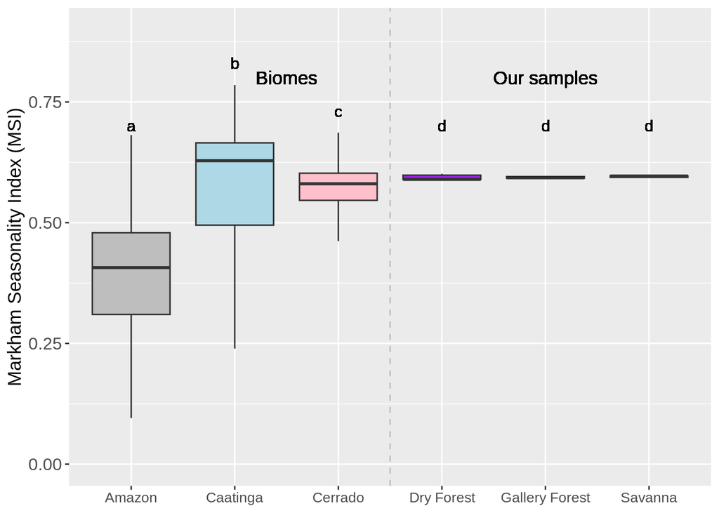

Figure 3: MSI distribution for Amazon, Caatinga and Cerrado Biomes, and for our sampled vegetation types.

# Conclusion

Gallery forests and savannas do not differ in MAP, but dry forests differ from them. Despite differences showed in the analysis of MAP for dry forests, the values are very close compared with the range of values for the Cerrado biome. Furthermore, all vegetation types are inside the bistability zone for MAP defined by Staver et al. (2011). Vegetation types do not differ in dry season length.

### REFERENCES

Ciemer, C., Boers, N., Hirota, M., Kurths, J., Müller-Hansen, F., Oliveira, R.S., & Winkelmann, R. (2019). Higher resilience to climatic disturbances in tropical vegetation exposed to more variable rainfall. Nat. Geosci. 12, 174–179. https://doi.org/10.1038/s41561-019-0312-z

Markham, C. G. (1970). Seasonality of precipitation in the United States. Annals of the Association of American Geographers, 60(3), 593–597. https://doi.org/10.1111/J.1467-8306.1970.TB00743.X

Pinheiro J, Bates D, DebRoy S, Sarkar D, R Core Team (2019). *nlme: Linear and Nonlinear Mixed Effects Models*. R package version 3.1-140, <URL: https://CRAN.R-project.org/package=nlme>

Lenth, R.V. (2022). emmeans: Estimated Marginal Means, aka Least-Squares Means. R package version 1.7.4-1. https://CRAN.R-project.org/package=emmeans

Staver, A. C., Archibald, S., & Levin, S. A. (2011). The global extent and determinants of savanna and forest as alternative biome states. Science, 230–232(334). https://doi.org/10.1126/science.1210465